# Bayesian multilevel models

Jörn Alexander Quent

11 November 2019

# Example data

- Using a mutlilevel approach that includes stimulus and participants as crossed random effects (Judd et al., 2012).
- Stroop task:
  - 26 participants,
  - On average 191 trials per participant,
  - Congruency: 4 incongruent vs 4 neutral words.

$$RT \sim congruency + (congruency | subNum) + (1 | stimulus)$$

# BRMS vs. lme4

Syntax the same

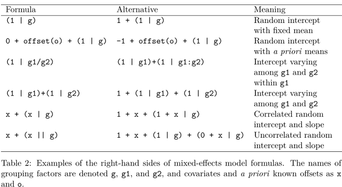

# BRMS vs. lme4

- Most functions still work, e.g. `ranef()` or `fixef()`.
- etc.
- BRMS uses MCMC etc.

# Our BRMS model

```r
# Priors based on reccommendations of Andrew Gelman
priors <- c(prior(normal(0, 1), class = "Intercept"),
            prior(normal(0, 1), class = "b"))

# Running full model
model_full <- brm(sRT ~ congruency + (congruency | subNum) + (1 | stimulus),
                  data = stroopData,
                  prior = priors,
                  save_all_pars = TRUE,
                  sample_prior = TRUE,
                  cores = cores2use)
```

# Our BRMS model

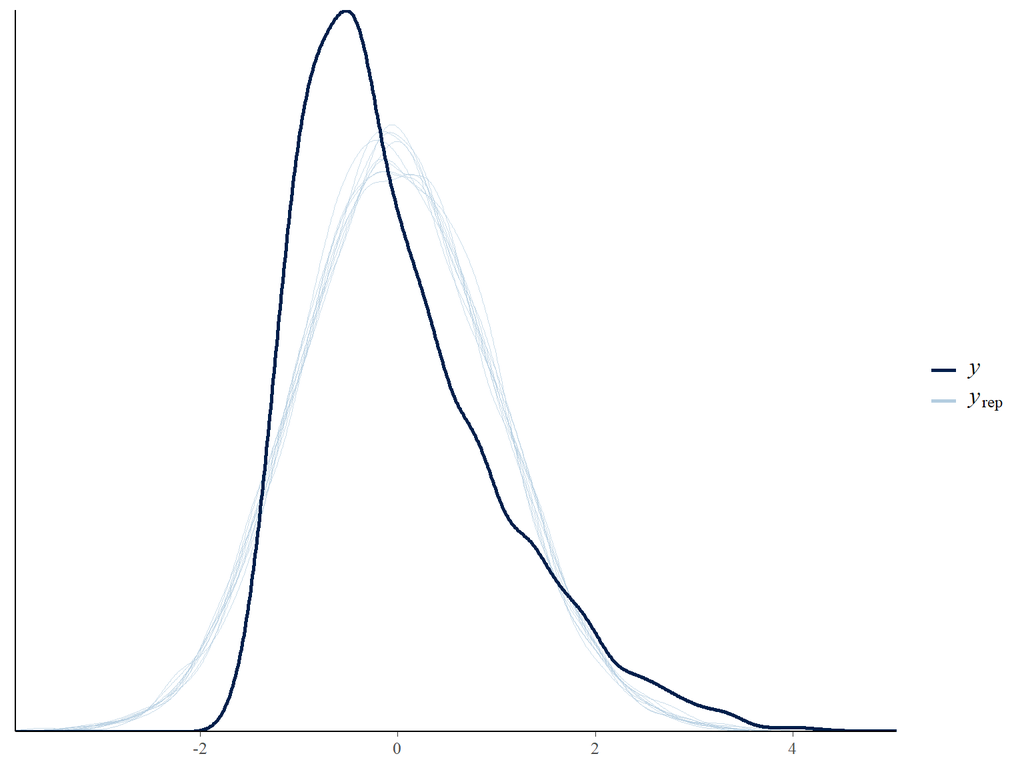

As we see in the posterior predictive check, a Gaussian distrubtion is the wrong link function.

# Our BRMS model

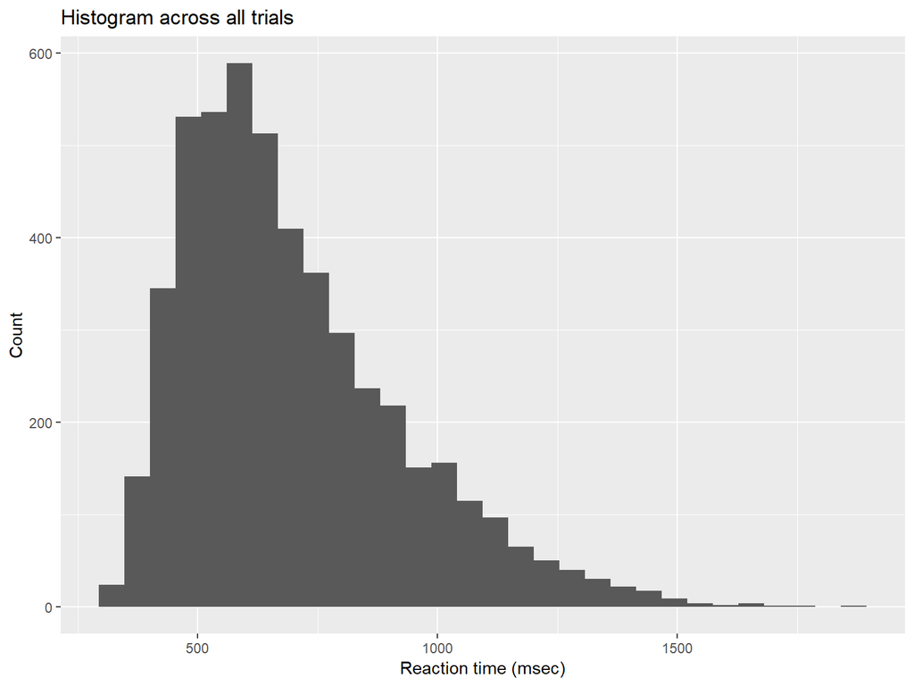

# Our BRMS model

- There is a considerable body literature that RT data follows an ex-Gaussian distribution rather than normal.
- For mean data is doesn’t matter because of central limit theorem but for non-aggregated data it does.

# Our BRMS model

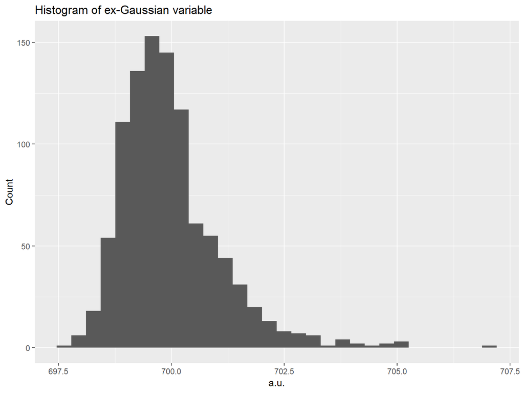

# Our BRMS model

```r
model_full_exGauss <- brm(sRT ~ congruency + (congruency | subNum) + (1 | stimulus),
                          family = exgaussian(link = "identity",
                                              link_sigma = "log",
                                              link_beta = "log"),
                          data = stroopData,
                          prior = priors,
                          save_all_pars = TRUE,
                          sample_prior = TRUE,
                          cores = cores2use)
```

# Our BRMS model

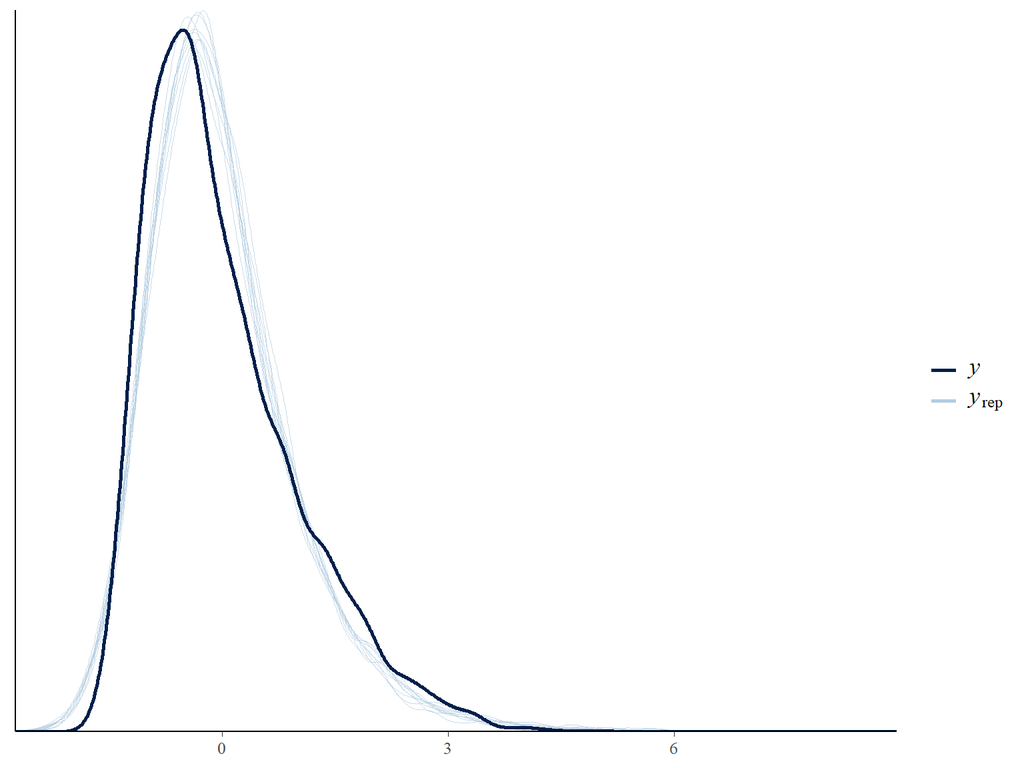

# What so special about Bayesian linear models

# Bayesian multilevel models

Let $\alpha$ be the common intercept and $\boldsymbol{\beta}$ be the common coefficients while $a_j$ is the deviation from the common intercept in the $j$-th group and $\mathbf{b}_j$ is the deviation from the common coefficients. Write the model as:
$$y_{ij} = \alpha + \sum_{k = 1}^K \beta_k x_{ik}+\underbrace{a_j + \sum_{k = 1}^K b_{jk} x_{ik}\overbrace{\boldsymbol{\epsilon}}^{\mbox{Bayesian error}}}_{\mbox{Frequentist error}}$$

Ben Goodrich, [Cambridge 2019](https://mc-stan.org/workshops/stancon2019_hierarchical/)

# Bayesian multilevel models

- Providing standard error and CI for parameters:
  - Random effects (lme4: `ranef()`)
  - Family parameters (lme4: `sigma()`)
- Using priors for
  - Shrinkage,
  - or using prior information.

# Our BRMS model

[output not shown]

# Bayesian interence

# Credible intervall

# Bayes factors

$$BF_{10} =\frac{likelihood\ of\ data\ given\ H_1}{likelihood\ of\ data\ given\ H_o} = \frac{P(D|H_1)}{P(D|H_0)}$$
- Instead of integrating out marginal likelihoods analytically, MCMC is used.

# MCMC

# A word on priors

- cautious,
- scaling is important

# Bayes factors

- bayes_factor,
- hypothesis, savage-dickey-ratio (special caveat about priors)
- general caveat of priors with example

# Bayes factor(s) from marginal likelihoods

# Savage-Dickey density ratio

# Savage-Dickey density ratio

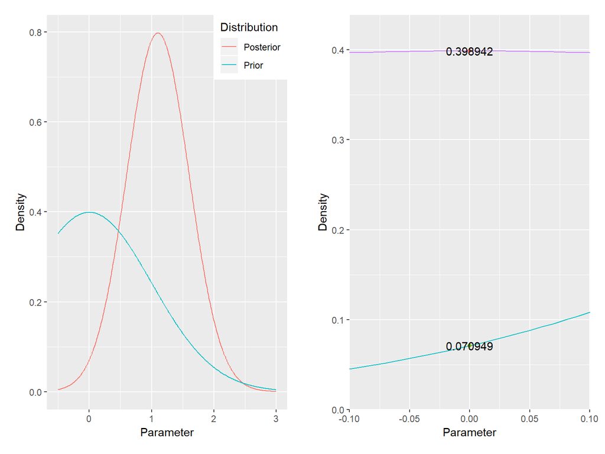

# Meta analysis

- sequential versus combinted analysis
- random effect analysis

# Drawback